# The relationship between non-profits and municipal spending on police protection

Nathan Duma

5/8/2021

# 1 Introduction

This notebook shows all data cleaning, data management and transformation steps, as well as all analyses and all graphics, including the code that was used to perform all of the above. I preform the data cleaning procedures (from start to finish) required to go from the raw data to the final *ready for analysis* dataset. I also show the graphics that made it into the final paper along with the summary statistics and regression tables. This document is intended as a supplement to the paper.

# 2 Data Cleaning

My project draws from three data sources: The first is Non-Profit data from the [*National Center* *for Charitable Statistics (NCCS)*](https://nccs-data.urban.org/index.php); The second is city level Crime data from an [American Sociological Review article](https://dataverse.harvard.edu/dataset.xhtml?persistentId=doi:10.7910/DVN/46WIH0) by Sharkey, Torrats-Espinosa, and Takyar (2017); The final data source is the [Fiscally Standardized Cities Database](https://www.lincolninst.edu/research-data/data-toolkits/fiscally-standardized-cities/search-database) which shows municipal spending on various budgetary categories.

**I will perform the following tasks:**

1. **NCCS Data:** Calculate the number of non-profits in a given category for each city-year.
2. **Sharkey Crime Data:** Subset to remove variables we don’t need and create balanced panel.
3. **Fiscal Data:** Subset to keep only years between 1990 - 2012. Drop varibales we don’t need.
4. Merge all three datasets.

```r
rm(list = ls())
pkgs <- c("readr", "dplyr", "readstata13", "stringr")
sapply(pkgs, library, character.only = TRUE, quietly = TRUE)
```

## 2.1 Non-Profits Data (NCCS)

In this section we use data on Non-Profit organizations released annually by the National Center for Charitable Statistics (NCCS), a part of the Center on Non-Profits and Philanthropy at the Urban Institute. This data is based of tax reporting data these Non-Profits make to the Internal Revenue Service (IRS). Specifically, we use data from the Cumulative Master File (CMF) which has data on all organizations that have tax exempt status with the IRS.

The Sharkey et al paper already provides us with data on the number of crime focused Non-Profits in each city. All we need is the number of environment focused Non-Profits. Following Sharkey et al we limit our data to 501(c)3 organizations.

The Cumulative Master File is very large (about 1.5GB) so we used the `readr` package which has functions optimized for quickly loading and querying large files in R. The data dictionary for the NCCS data can be found here.

```r
masterData <- read_delim("../Non Profit Data/nccs.nteedocAllEins.csv", ",", col_names = TRUE) # Current Master NTEE Lookup
crimeData <- read.dta13("../crime-nonprofits-panel.dta") # you'll need this before the Sharkey section (keep it here)
```

Lets start by subsetting and dropping portions of the data we don’t need. * The Non-Profits that NCCS has flagged as *out of scope*. There can be many reasons why a non-profit is flagged e.g. missing geographical info, Not a 501(c)3. * Non-Profits not active during our sample period i.e those whose last taxes were filed before 1990 (the year our study starts). * Non-Profits that are not 501(c)3

```r
# drop flagged non-profits
masterData <- subset(masterData, OutNccs == "IN")

# drop non-profits not active in sample period 1990 - 2012
masterData <- subset(masterData, UpdateFisYr >= 1990)

# drop non-501(c)3 non-profits
masterData <- subset(masterData, SubsecCd == "03")

# Subset based on Ntee Code classification rating A/B/C
masterData <- subset(masterData, nteeConfCO %in% c("A", "B", "C"))
```

Rule data is the date when the org got tax exempt status from the IRS. We can use it as a proxy for when the org was founded. The current variable is a string in the form YYYYMM. We need to convert it to YYYY.

```r
masterData$RuleDate <- substr(masterData$RuleDate, start = 1, stop = 4)
masterData$RuleDate <- as.numeric(masterData$RuleDate)
masterData <- subset(masterData, RuleDate != 0)
```

Next we can classify the Non-Profits by sector using the [NTEE/IRS Activity Codes](https://nccs.urban.org/publication/irs-activity-codes). I’m primarily interested in the Environmental Non-Profits but I also collect data for Animal Welfare, Crime, Housing and Disaster Preparedness non-profits just in case I find a use for those values.

- **C:** Environment - Private nonprofit organizations whose primary purpose is to preserve, protect and improve the environment.
- **D:** Animal-Related Private nonprofit organizations whose primary purpose is to provide for the care, protection and control of wildlife and domestic animals that are a part of the living environment; to help people develop an understanding of their pets; and to train animals for purposes of showing.
- **I:** Crime and Legal Related
- **L:** Housing & Shelter
- **M:** Public Safety, Disaster Preparedness & Relief

```r
nteeCodes <- c("C", "D", "I", "L", "M")
nteeDescA <- c("envmt_new", 'animal_new', "crime_new", "housing_new", "disaster_new") # var names new charities
nteeDescB <- c("envmt_cml", 'animal_cml', "crime_cml", "housing_cml", "disaster_cml") # var names cumulative no.

masterData$NteeFinal <- substr(masterData$NteeFinal, start = 1, stop = 1) # keep only first letter of classification
masterData <- subset(masterData, NteeFinal %in% nteeCodes)
```

### 2.1.1 Number of New Non-Profits Each Year

It’s easier to calculate the number of new non-profits in each given city-year for each sector, so we’ll start with that. To make sure I’m getting the same cities in the Sharkey et al dataset I’ll load it in now and keep only cities that are in that dataset.

```r
suffix <- c(" (balance)"," city", "town", " municipality")
for(elem in suffix){
  # remove suffixes from city names
  crimeData$place_name <- gsub(elem, "", crimeData$place_name)
}

# matching variable for cities
crimeData$matchCity <- paste(crimeData$state_ab, crimeData$place_name, sep = ": ")
# View(crimeData[,c(1:7,292)]) # check correctness
```

```r
# Capitalize the first letter of each word
masterData$City <- stringr::str_to_title(masterData$City)
# matching variable for cities
masterData$matchCity <- paste(masterData$State, masterData$City, sep = ": ")
length(unique(masterData$matchCity)) # 20,984 unique cities/towns
```

```
## [1] 20984
```

```r
sum(unique(masterData$matchCity) %in% crimeData$matchCity) # 259 cities from the non-profit dataset are also in the crime dataset
```

```
## [1] 260
```

```r
# Now subset to keep only those cities
masterData <- subset(masterData, matchCity %in% crimeData$matchCity)


newCharities <- masterData %>% filter(RuleDate %in% 1990:2012) %>%
  group_by(matchCity, RuleDate, NteeFinal) %>%
  count()

# assign charity category names
newCharities$category <- NA

for(j in 1:length(nteeCodes)){
  # recoding to full category names
  newCharities$category <- ifelse(newCharities$NteeFinal == nteeCodes[j], nteeDescA[j], newCharities$category)
}


head(newCharities)
```

```
## # A tibble: 6 x 5
## # Groups:   matchCity, RuleDate, NteeFinal [6]
##   matchCity     RuleDate NteeFinal     n category
##   <chr>            <dbl> <chr>     <int> <chr>
## 1 AK: Anchorage     1990 C             1 envmt_new
## 2 AK: Anchorage     1990 D             1 animal_new
## 3 AK: Anchorage     1991 C             1 envmt_new
## 4 AK: Anchorage     1991 L             1 housing_new
## 5 AK: Anchorage     1991 M             1 disaster_new
## 6 AK: Anchorage     1992 D             3 animal_new
```

Next we’ll need to reshape the resulting dataframe to make the categories columns.

```r
newCharities <- newCharities[,c(1,2,5,4)]
newCharities <- reshape::cast(newCharities, matchCity+RuleDate~category)
newCharities[,3:7] <- sapply(newCharities[,3:7], function(x) ifelse(is.na(x), 0, x)) # replace NA's with zeros
cat("This is what the variables for number of new charities in each year look like\n")
```

```
## This is what the variables for number of new charities in each year look like
```

```r
head(newCharities)
```

```
##       matchCity RuleDate animal_new crime_new disaster_new envmt_new
## 1 AK: Anchorage     1990          1         0            0         1
## 2 AK: Anchorage     1991          0         0            1         1
## 3 AK: Anchorage     1992          3         1            0         0
## 4 AK: Anchorage     1993          3         0            0         0
## 5 AK: Anchorage     1994          1         2            1         1
## 6 AK: Anchorage     1995          0         1            0         2
##   housing_new
## 1           0
## 2           1
## 3           2
## 4           1
## 5           2
## 6           2
```

### 2.1.2 Cumulative Number of Non-Profits in each Year

Here we assume that a charity is active from the time it gains tax exempt status (`RuleDate`) until the year of its last tax return (`UpdateFisYr`). This part is much more involved, the code works but is unspeakably slow.

```r
yearRange <- 1990:2016


for(elem in yearRange){masterData[[paste("In", elem, sep = "_")]] <- NA} # create year dummy variables
# View(masterData[,c(2,4,5,20,15,63,118:144)])
masterData[, c(118:144)] <- sapply(masterData[, c(118:144)], FUN = as.numeric) # convert from boolean to numeric

dummyColumns <- names(masterData)[118:144]


for(row in 1:nrow(masterData)){
  # iterate over the rows of the dataset
  for(col in 1: length(yearRange)){
    # find if a given charity existed in a given year, code the dummy for that yr as 1 otherwise zero
    masterData[row, dummyColumns[col]] <- ifelse(yearRange[col] %in% masterData$RuleDate[row] : masterData$UpdateFisYr[row], 1, 0)
  }
}


# View(masterData[,c(2,4,5,20, 15,63,118:144)]) # check if it worked

head(masterData[,c(1,4,5,20,15,63,118:144)])
```

```
## # A tibble: 6 x 33
##   EIN      State City     NteeFinal RuleDate UpdateFisYr In_1990 In_1991 In_1992
##   <chr>    <chr> <chr>    <chr>        <dbl>       <dbl>   <dbl>   <dbl>   <dbl>
## 1 0000031~ VA    Norfolk  C             2014        2016       0       0       0
## 2 0021934~ DC    Washing~ L             1973        2010       1       1       1
## 3 0033188~ CA    Sacrame~ I             2006        2010       0       0       0
## 4 0103597~ MA    Cambrid~ C             1980        2006       1       1       1
## 5 0103721~ WI    Madison  C             1990        2016       1       1       1
## 6 0103748~ MD    Baltimo~ C             1982        2016       1       1       1
## # ... with 24 more variables: In_1993 <dbl>, In_1994 <dbl>, In_1995 <dbl>,
## #   In_1996 <dbl>, In_1997 <dbl>, In_1998 <dbl>, In_1999 <dbl>, In_2000 <dbl>,
## #   In_2001 <dbl>, In_2002 <dbl>, In_2003 <dbl>, In_2004 <dbl>, In_2005 <dbl>,
## #   In_2006 <dbl>, In_2007 <dbl>, In_2008 <dbl>, In_2009 <dbl>, In_2010 <dbl>,
## #   In_2011 <dbl>, In_2012 <dbl>, In_2013 <dbl>, In_2014 <dbl>, In_2015 <dbl>,
## #   In_2016 <dbl>
```

Now we can just sum up the dummy columns to find out the cumulative number of charities in a given year.

```r
cumlCharities <- masterData %>% filter(RuleDate <= 2012) %>%
  group_by(matchCity, NteeFinal) %>%
  select(In_1990:In_2012) %>%
  summarise(across(everything(), function(x) sum(x, na.rm = T)))
# assign charity category names
cumlCharities$category <- NA

for(j in 1:length(nteeCodes)){
  # recoding to full category names
  cumlCharities$category <- ifelse(cumlCharities$NteeFinal == nteeCodes[j], nteeDescB[j], cumlCharities$category)
}

# View(cumlCharities[,c(1,2,26)]) # it worked

cumlCharitiesBackup <- cumlCharities
cumlCharities <- as.data.frame(cumlCharities)

cumlCharities <- reshape::melt(cumlCharities[,-2], id = c("matchCity", "category"))
cumlCharities$variable <- as.character(cumlCharities$variable)
cumlCharities$variable <- as.numeric(gsub("In_", "", cumlCharities$variable))
cumlCharities <- reshape::cast(cumlCharities, matchCity + variable ~ category)

allCharities <- merge(cumlCharities, newCharities, by.x = c("matchCity", "variable"), by.y = c("matchCity", "RuleDate"), all.x = TRUE)

allCharities[,c(8:12)] <- sapply(allCharities[,c(8:12)], FUN = function(x) ifelse(is.na(x), 0, x)) # replace NAs with zeros
```

**The final output for the number of non-profit variables looks like this**

```
##       matchCity variable animal_cml crime_cml disaster_cml envmt_cml
## 1 AK: Anchorage     1990          6        11            6        19
## 2 AK: Anchorage     1991          6        11            7        20
## 3 AK: Anchorage     1992          9        12            7        20
## 4 AK: Anchorage     1993         12        12            7        20
## 5 AK: Anchorage     1994         13        14            8        21
## 6 AK: Anchorage     1995         13        15            8        23
##   housing_cml animal_new crime_new disaster_new envmt_new housing_new
## 1           9          1         0            0         1           0
## 2          10          0         0            1         1           1
## 3          12          3         1            0         0           2
## 4          13          3         0            0         0           1
## 5          15          1         2            1         1           2
## 6          17          0         1            0         2           2
```

## 2.2 Crime Data

We’ve already loaded in the crime data. All we need to do with this data is to subset it keeping only the variables we care about.

```r
crimeData <- crimeData[,c(292,1:104)]
head(crimeData[,c(1,3,5,21,23,40,41)])
```

```
##        matchCity                 agency year   viol_r   murd_r crime_new
## 1 AL: Birmingham Birmingham Police Dept 1990 1476.117 46.99813         1
## 2 AL: Birmingham Birmingham Police Dept 1991 2514.288 52.72077         0
## 3 AL: Birmingham Birmingham Police Dept 1992 2212.457 50.89187         0
## 4 AL: Birmingham Birmingham Police Dept 1993 2463.482 46.71389         0
## 5 AL: Birmingham Birmingham Police Dept 1994 2474.399 52.58877         0
## 6 AL: Birmingham Birmingham Police Dept 1995 2516.176 47.56401         0
##   crime_cml
## 1         3
## 2         3
## 3         3
## 4         3
## 5         3
## 6         3
```

## 2.3 Fiscal Data

In this section we load in clean and subset the city-level spending data from the Fiscally Standardized Cities Database.

```r
fiscalData <- readxl::read_xlsx("../fisc_full_dataset_2017_update.xlsx", sheet = "Data")
fiscalData <- fiscalData[,c(1:3,5,7:14,76,80:82)]
fiscalData <- subset(fiscalData, year %in% 1990:2012) # subset to sample period
head(fiscalData[,c(1,2,5,6,13,14)])
```

```
## # A tibble: 6 x 6
##    year city_name   rev_total_city rev_general_city police_city envir_housing_c~
##   <dbl> <chr>                <dbl>            <dbl>       <dbl>            <dbl>
## 1  1990 AK: Anchor~          6347.            5396.        294.             390.
## 2  1991 AK: Anchor~          6239.            5311.        303.             381.
## 3  1992 AK: Anchor~          6055.            5170.        294.             394.
## 4  1993 AK: Anchor~          6293.            5443.        312.             505.
## 5  1994 AK: Anchor~          5611.            4734.        294.             306.
## 6  1995 AK: Anchor~          5551.            4756.        249.             292.
```

## 2.4 Merging the Datasets

The last part of the data cleaning is to merge all the datasets. The fiscal data has the lowest number of cities so the max number of cities in our final data is 218.

We start of by checking how well the cities between the two datasets match.

```r
sum(unique(fiscalData$city_name) %in% unique(allCharities$matchCity)) # 121 cities in both the fiscal & charities data
```

```
## [1] 121
```

```r
# find the unmatched cities
unmatched <- which(!unique(fiscalData$city_name) %in% unique(allCharities$matchCity))

cat("Number of Unmatched cities\n")
```

```
## Number of Unmatched cities
```

```r
length(unmatched)
```

```
## [1] 97
```

```r
# cat("A list of currently unmatched cities \n")
# unique(fiscalData$city_name)[unmatched]
```

There are lots of currently unmatched cities because of small differences in the naming conventions. A lot of this can be recovered latter. As we currently stand our final dataset will have 121 cities but that can be expanded to 150.

```r
xMerge <- merge(allCharities, crimeData, by.x = c("matchCity", "variable"), by.y = c("matchCity", "year"), all.x = TRUE)

fiscalData <- subset(fiscalData, city_name %in% xMerge$matchCity)

yMerge <- merge(fiscalData, xMerge, by.x = c("city_name", "year"), by.y = c("matchCity", "variable"), all.x = TRUE)
```

Finally, we write and output our final dataset. It has 121 cities just like we expected.

```r
length(unique(yMerge$city_name)) # 121 cities
```

```
## [1] 121
```

```r
write.csv(yMerge, file = "FinalData.csv", row.names = F, quote = T)
```

# 3 Visualization

In Exercise 4 of the class I created a number of visualizations. Only one of these made it into the paper. The plot is a heatmap that shows the correlation between the most important variables for the study. I used the `pheatmap` and `RColorBrewer` packages. The later is for selecting attractive color palettes.

```r
library(pheatmap)
library(RColorBrewer)
library(pdftools)
finalData <- read.csv("FinalData.csv")
rm(list = ls()[! ls() %in% "finalData"]) # remove everything except the finalData
```

**We start by preparing the data for the plot**

```r
# prep plot data
keepVars <- c("police_city","rev_total_city", "totpop", "crime_cml_r", "viol_r", "prop_r", "poverty", "fborn", "unemployed_male")

corData <- subset(finalData, select = keepVars)

names(corData) <- c("Police Spending", "Total Revenue", "Population", "Cuml Crime Charities", "Violent Crime Rate", "Property Crime Rate", "% in Poverty", "% Foreign Born", "Unemployment Rate (male)")

corData <- cor(corData, use = "complete")
```

**Next, we create the plot itself.**

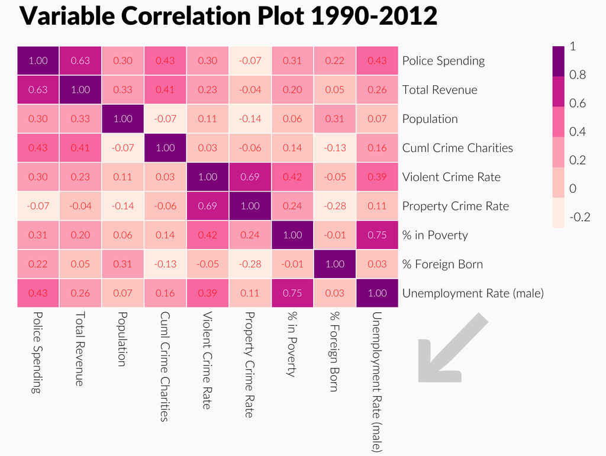

```r
# begin plot
pdf_file <- "correlation_heatmap.pdf"

cairo_pdf(bg = "grey98", pdf_file, width = 7,height = 6)
par(mai = c(0.25, 0.25, 0.25, 1.75), omi = c(0.25,0.25,0.75,0.85), family = "Lato Light", las = 1)


# Create chart
plot.new()

pheatmap(corData, col = brewer.pal(6,"RdPu"), cluster_rows = F, cluster_cols = F, cellwidth = 35, cellheight = 24,
         border_color="white", fontfamily = "Lato Light", display_numbers = T, number_color = matrix(ifelse(corData > 0.5, "white", "red"), nrow(corData)))


# Titling
# mtext(expression(bold("Variable Correlation Plot 1990-2012")), 3, line = 1.5, adj = 0, cex = 1.75, outer=T)
mtext("Variable Correlation Plot 1990-2012", 3, line = 1.5, adj = 0, cex = 1.75, family = "Lato Black", outer=T)

par(family = "Lato Black")
mtext("\u2199", 1, line = -7,adj = 0.9, cex = 7, col = "grey80", outer = T)
dev.off()
```

# 4 Summary Statistics

Before moving on to the analysis, I first show the summary statistics. In the paper, these appear in `Table 2`.

We start by removing cities with missing and anomalous values (e.g. police spending value of zero).

```r
panelData <- finalData[,c(1,2,31,5, 13,45,47,49,51,53,55,57,59,61,64,65,84,85,99:103,105:108,110,115,116,119,123,124,125,128,129)]
incompleteCities <- unique(panelData[!complete.cases(panelData),"city_name"]) # list incomplete cities
zeroPolice <- unique(panelData[panelData$police_city == 0, "city_name"]) # cities with zero police spending

panelData <- panelData[!panelData$city_name %in% incompleteCities, ] # remove incomplete cities
panelData <- panelData[!panelData$city_name %in% zeroPolice, ] # remove zero police
length(unique(panelData$city_name)) # 100 cities with complete observations
```

```
## [1] 100
```

**Table 2 with the summary statistics is below:**

```r
library(stargazer)
# Summary Statistics

varList <- c("police_city", "rev_total_city","crime_new_r", "crime_cml_r", "totpop", "viol_r", "prop_r", "black", "college", "unemployed", "poverty", "male1524")

stargazer(panelData[,names(panelData) %in% varList], type = "html", title = "Table 2. Summary Statistics", out = "SumStat2.html",
          summary.stat = c("n", "mean", "sd", "min", "max"), digits = 2)
```

**Table 2. Summary Statistics**

| Statistic | N | Mean | St. Dev. | Min | Max |
| --- | --- | --- | --- | --- | --- |
| totpop | 2,300 | 485,992.30 | 874,869.40 | 74,111 | 8,265,011 |
| rev_total_city | 2,300 | 3,106.04 | 1,897.32 | -1,258.38 | 14,189.00 |
| police_city | 2,300 | 295.96 | 104.33 | 3.49 | 772.65 |
| viol_r | 2,300 | 951.42 | 603.76 | 0.00 | 4,269.44 |
| prop_r | 2,300 | 6,225.40 | 2,398.63 | 0.00 | 15,380.10 |
| crime_new_r | 2,300 | 0.19 | 0.30 | 0 | 2 |
| crime_cml_r | 2,300 | 3.57 | 2.38 | 0.00 | 14.99 |
| black | 2,300 | 21.62 | 18.26 | 0.25 | 78.37 |
| college | 2,300 | 27.35 | 8.54 | 8.06 | 56.39 |
| unemployed | 2,300 | 5.12 | 1.49 | 2.19 | 12.02 |
| male1524 | 2,300 | 8.32 | 1.93 | 5.23 | 19.24 |
| poverty | 2,300 | 18.18 | 6.01 | 4.25 | 34.50 |

# 5 Panel Regression Model

In this section I run a set of 5 regression models. The models gradually become more restrictive as we go from model 1 up to model 5 which has both city and time fixed effects in addition to having the dynamic panel specification. I used the `plm` package for this.

The first step is to prep the data for the regression models. I need to do the following:

1. Lag the independent variables by one year using the `data.table` package.
2. Where appropriate, mean center the independent variables by using z-score standardization.
3. Create population weights for the regression models, using **1990** as the base year.

```r
library(lmtest)
library(sandwich)
library(ivreg)
library(plm)
panelData <- panelData[,c(1,32,2:31,33:36)]

# Population weights

pop1990 <- panelData[panelData$year == 1990, c(1,4)]
panelData$pop_weight <- pop1990$totpop[match(panelData$city_name, pop1990$city_name)]
panelData <- panelData[, c(1:4,37,5:36)]

# Lag by independent var by one year
library(data.table)
panelData <- as.data.table(panelData) # convert to data table
toLagList <- names(panelData)[6:37]
nm2 <- paste(toLagList, 1, sep="_")
panelData[, (nm2):=lapply(.SD, function(x) c(NA, x[-.N])), by = city_name, .SDcols = toLagList]


# Z Score standardize the lagged variables
panelData <- as.data.frame(panelData)
stdNames <- paste(names(panelData)[38:69], "std", sep = "_") # give std suffix to stand variables
stdPanel <- as.data.frame(apply(panelData[,38:69], 2, function(x) scale(x)))
names(stdPanel) <- stdNames
panelData <- cbind(panelData, stdPanel)
```

## 5.1 Run Panel Models

The first step is to set our data as a panel and define the regression formulas. The `plm` package which we used for the dynamic panel model does not yet support regression weights of instrumental variable models, so we instead use the log of total population as a conrtrol variable in our model.

```r
panelData <- pdata.frame(panelData, index = c("city_name", "year"))

regFormula1 <- formula(police_city ~ crime_cml_r_1 + rev_total_city_1 + viol_r_1 + prop_r_1 + log(totpop) + popdens_1 + black_1 + fborn_1 + male1524_1 + college_1 + unemployed_male_1 + poverty_1 |
iv_cml_r_1 + rev_total_city_1 + viol_r_1 + prop_r_1 + log(totpop) + popdens_1 + black_1 + fborn_1 + male1524_1 + college_1 + unemployed_male_1 + poverty_1) # no year dummy variables, lagged indpdt vars but not standardized


regFormula1A <- formula(police_city ~ crime_cml_r_1_std + rev_total_city_1_std + viol_r_1_std + prop_r_1_std + log(totpop) + popdens_1_std + black_1_std + fborn_1_std + male1524_1_std + college_1_std + unemployed_male_1_std + poverty_1_std |
iv_cml_r_1_std + rev_total_city_1_std + viol_r_1_std + prop_r_1_std + log(totpop) + popdens_1_std + black_1_std + fborn_1_std + male1524_1_std + college_1_std +
unemployed_male_1_std + poverty_1_std) # no year dummy variables, lagged standardized indpdt vars


regFormula2 <- formula(police_city ~ crime_cml_r_1 + rev_total_city_1 + viol_r_1 + prop_r_1 + log(totpop) + popdens_1 + black_1 + fborn_1 + male1524_1 + college_1 + unemployed_male_1 + poverty_1 + factor(year)|
iv_cml_r_1 + rev_total_city_1 + viol_r_1 + prop_r_1 + log(totpop) + popdens_1 + black_1 + fborn_1 + male1524_1 + college_1 +
 unemployed_male_1 + poverty_1 + factor(year)) # year dummy variables, lagged indpdt vars but not standardized


regFormula2A <- formula(police_city ~ crime_cml_r_1_std + rev_total_city_1_std + viol_r_1_std + prop_r_1_std + log(totpop) + popdens_1_std + black_1_std + fborn_1_std + male1524_1_std + college_1_std + unemployed_male_1_std + poverty_1_std + factor(year) |
iv_cml_r_1_std + rev_total_city_1_std + viol_r_1_std + prop_r_1_std + log(totpop) + popdens_1_std + black_1_std + fborn_1_std + male1524_1_std + college_1_std + unemployed_male_1_std + poverty_1_std + factor(year)) # year dummy variables, lagged standardized indpdt vars
```

The first regression model is a simple instrumental variables regression without city or time fixed effects. The number of environmental and arts charities is used as an instrument for the number of **crime focused non-profits**.

```r
model.fit1 <- ivreg(regFormula1A, data = panelData)
summary(model.fit1)
```

```
##
## Call:
## ivreg(formula = regFormula1A, data = panelData)
##
## Residuals:
##      Min       1Q   Median       3Q      Max
## -281.348  -51.101   -9.893   38.793  453.647
##
## Coefficients:
##                       Estimate Std. Error t value Pr(>|t|)
## (Intercept)           139.4903    32.5198   4.289 1.87e-05 ***
## crime_cml_r_1_std      44.3022     4.2369  10.456  < 2e-16 ***
## rev_total_city_1_std   22.4235     2.0685  10.840  < 2e-16 ***
## viol_r_1_std           14.6326     2.7344   5.351 9.65e-08 ***
## prop_r_1_std           -0.7084     2.6475  -0.268  0.78907
## log(totpop)            12.5614     2.5664   4.895 1.06e-06 ***
## popdens_1_std          26.0435     2.6683   9.760  < 2e-16 ***
## black_1_std            14.7264     2.4565   5.995 2.37e-09 ***
## fborn_1_std            25.6610     2.4004  10.690  < 2e-16 ***
## male1524_1_std         -3.0656     2.6075  -1.176  0.23986
## college_1_std          -9.3467     3.1063  -3.009  0.00265 **
## unemployed_male_1_std  23.0671     2.6916   8.570  < 2e-16 ***
## poverty_1_std         -16.3783     3.7937  -4.317 1.65e-05 ***
##
## Diagnostic tests:
##                   df1  df2 statistic p-value
## Weak instruments    1 2187    650.08  <2e-16 ***
## Wu-Hausman          1 2186     83.54  <2e-16 ***
## Sargan              0   NA        NA      NA
## ---
## Signif. codes:  0 '***' 0.001 '**' 0.01 '*' 0.05 '.' 0.1 ' ' 1
##
## Residual standard error: 73.96 on 2187 degrees of freedom
## Multiple R-Squared: 0.5024,  Adjusted R-squared: 0.4997
## Wald test: 209.9 on 12 and 2187 DF,  p-value: < 2.2e-16
```

```r
# Huber-White standard errors
model.fit1A <- coeftest(model.fit1, vcovHC(model.fit1, type = "HC0", cluster = "city_name"))
```

The second regression model is a standard panel model (i.e., not a dynamic panel model) which includes city fixed effect but not time fixed effects.

```r
model.fit2 <- plm(regFormula1A, data = panelData, model = "within")
summary(model.fit2)
```

```
## Oneway (individual) effect Within Model
## Instrumental variable estimation
##
## Call:
## plm(formula = regFormula1A, data = panelData, model = "within")
##
## Balanced Panel: n = 100, T = 22, N = 2200
##
## Residuals:
##      Min.   1st Qu.    Median   3rd Qu.      Max.
## -346.2190  -22.1269   -2.8317   17.6815  344.2238
##
## Coefficients:
##                        Estimate Std. Error z-value  Pr(>|z|)
## crime_cml_r_1_std      23.70288    6.36199  3.7257 0.0001948 ***
## rev_total_city_1_std   10.60623    3.28690  3.2268 0.0012518 **
## viol_r_1_std           -7.72102    2.47466 -3.1200 0.0018083 **
## prop_r_1_std           -0.65359    2.80682 -0.2329 0.8158721
## log(totpop)           -65.86318   21.09659 -3.1220 0.0017964 **
## popdens_1_std          66.32209   22.17620  2.9907 0.0027835 **
## black_1_std            64.55015   13.90212  4.6432 3.431e-06 ***
## fborn_1_std            54.82745    8.31647  6.5926 4.321e-11 ***
## male1524_1_std         -6.48166    5.30642 -1.2215 0.2219057
## college_1_std          23.96228    8.14496  2.9420 0.0032613 **
## unemployed_male_1_std   9.77417    3.30913  2.9537 0.0031399 **
## poverty_1_std         -24.48933    6.86210 -3.5688 0.0003586 ***
## ---
## Signif. codes:  0 '***' 0.001 '**' 0.01 '*' 0.05 '.' 0.1 ' ' 1
##
## Total Sum of Squares:    5830600
## Residual Sum of Squares: 3535800
## R-Squared:      0.39419
## Adj. R-Squared: 0.36198
## Chisq: 1392.34 on 12 DF, p-value: < 2.22e-16
```

```r
# Huber-White standard errors
model.fit2A <- coeftest(model.fit2, vcovHC(model.fit2, type = "HC0", cluster = "group"))
```

The third model is a standard panel model (i.e., not a dynamic panel model) which includes time fixed effects only.

```r
model.fit3 <- ivreg(regFormula2A, data = panelData)
summary(model.fit3)
```

```
##
## Call:
## ivreg(formula = regFormula2A, data = panelData)
##
## Residuals:
##      Min       1Q   Median       3Q      Max
## -271.941  -49.505   -8.937   38.252  437.814
##
## Coefficients:
##                       Estimate Std. Error t value Pr(>|t|)
## (Intercept)            127.126     32.123   3.958 7.82e-05 ***
## crime_cml_r_1_std       37.137      4.925   7.540 6.86e-14 ***
## rev_total_city_1_std    21.869      2.017  10.840  < 2e-16 ***
## viol_r_1_std            16.340      2.693   6.067 1.53e-09 ***
## prop_r_1_std             3.698      2.805   1.318 0.187516
## log(totpop)             11.565      2.531   4.570 5.15e-06 ***
## popdens_1_std           28.246      2.625  10.761  < 2e-16 ***
## black_1_std             14.028      2.397   5.852 5.61e-09 ***
## fborn_1_std             22.939      2.432   9.431  < 2e-16 ***
## male1524_1_std          -2.594      2.478  -1.047 0.295283
## college_1_std           -8.640      2.959  -2.920 0.003536 **
## unemployed_male_1_std   22.420      2.765   8.110 8.41e-16 ***
## poverty_1_std          -17.828      3.618  -4.928 8.94e-07 ***
## factor(year)1992         2.889     10.151   0.285 0.775962
## factor(year)1993         5.728     10.161   0.564 0.572978
## factor(year)1994         8.349     10.189   0.819 0.412636
## factor(year)1995         6.965     10.221   0.681 0.495709
## factor(year)1996        14.622     10.291   1.421 0.155484
## factor(year)1997        18.786     10.393   1.808 0.070805 .
## factor(year)1998        22.550     10.530   2.141 0.032351 *
## factor(year)1999        28.566     10.716   2.666 0.007741 **
## factor(year)2000        31.048     10.906   2.847 0.004457 **
## factor(year)2001        31.768     11.002   2.887 0.003922 **
## factor(year)2002        39.098     11.125   3.514 0.000450 ***
## factor(year)2003        39.429     11.239   3.508 0.000460 ***
## factor(year)2004        32.965     11.456   2.878 0.004047 **
## factor(year)2005        29.346     11.626   2.524 0.011667 *
## factor(year)2006        28.840     11.802   2.444 0.014618 *
## factor(year)2007        35.743     11.949   2.991 0.002809 **
## factor(year)2008        33.099     12.192   2.715 0.006685 **
## factor(year)2009        47.356     12.381   3.825 0.000135 ***
## factor(year)2010        47.559     12.668   3.754 0.000178 ***
## factor(year)2011        27.427     12.945   2.119 0.034222 *
## factor(year)2012        17.282     13.139   1.315 0.188557
##
## Diagnostic tests:
##                   df1  df2 statistic  p-value
## Weak instruments    1 2166    478.86  < 2e-16 ***
## Wu-Hausman          1 2165     58.01 3.88e-14 ***
## Sargan              0   NA        NA       NA
## ---
## Signif. codes:  0 '***' 0.001 '**' 0.01 '*' 0.05 '.' 0.1 ' ' 1
##
## Residual standard error: 71.75 on 2166 degrees of freedom
## Multiple R-Squared: 0.5362,  Adjusted R-squared: 0.5292
## Wald test: 84.34 on 33 and 2166 DF,  p-value: < 2.2e-16
```

```r
# Huber-White standard errors
model.fit3A <- coeftest(model.fit3, vcovHC(model.fit3, type = "HC0", cluster = "city_name"))
```

Model 4 includes both city and time fixed effect but it is not a dynamic panel model.

```r
model.fit4 <- plm(regFormula2A, data = panelData, model = "within")
summary(model.fit4)
```

```
## Oneway (individual) effect Within Model
## Instrumental variable estimation
##
## Call:
## plm(formula = regFormula2A, data = panelData, model = "within")
##
## Balanced Panel: n = 100, T = 22, N = 2200
##
## Residuals:
##      Min.   1st Qu.    Median   3rd Qu.      Max.
## -338.6318  -20.6485   -2.2654   16.8930  339.3479
##
## Coefficients:
##                        Estimate Std. Error z-value  Pr(>|z|)
## crime_cml_r_1_std        5.7660     7.8193  0.7374 0.4608815
## rev_total_city_1_std     8.7896     3.4387  2.5561 0.0105853 *
## viol_r_1_std            -8.7734     2.4676 -3.5555 0.0003772 ***
## prop_r_1_std             3.5393     2.7482  1.2879 0.1977972
## log(totpop)           -101.5138    21.8006 -4.6565 3.217e-06 ***
## popdens_1_std           50.4660    21.7053  2.3251 0.0200693 *
## black_1_std             48.3642    13.2518  3.6496 0.0002626 ***
## fborn_1_std             46.1700     8.6634  5.3293 9.860e-08 ***
## male1524_1_std          -3.7790     5.2307 -0.7225 0.4700056
## college_1_std            5.3553     7.8925  0.6785 0.4974357
## unemployed_male_1_std   10.1491     3.3654  3.0158 0.0025634 **
## poverty_1_std          -39.7708     7.3703 -5.3961 6.812e-08 ***
## factor(year)1992         6.2457     5.6570  1.1041 0.2695644
## factor(year)1993         8.8240     5.7275  1.5406 0.1234046
## factor(year)1994        12.4420     5.8586  2.1237 0.0336925 *
## factor(year)1995        11.1360     6.0493  1.8409 0.0656389 .
## factor(year)1996        17.6956     6.3824  2.7726 0.0055616 **
## factor(year)1997        21.2294     6.7791  3.1316 0.0017387 **
## factor(year)1998        26.1260     7.2847  3.5864 0.0003353 ***
## factor(year)1999        30.1042     7.7910  3.8640 0.0001116 ***
## factor(year)2000        31.2702     8.2559  3.7876 0.0001521 ***
## factor(year)2001        33.5931     8.6936  3.8641 0.0001115 ***
## factor(year)2002        45.5175     9.0551  5.0267 4.990e-07 ***
## factor(year)2003        48.8112     9.3861  5.2003 1.989e-07 ***
## factor(year)2004        47.0235     9.9088  4.7456 2.079e-06 ***
## factor(year)2005        49.4089    10.3091  4.7927 1.645e-06 ***
## factor(year)2006        53.2106    10.6409  5.0006 5.717e-07 ***
## factor(year)2007        65.4002    10.9648  5.9646 2.453e-09 ***
## factor(year)2008        67.7767    11.4792  5.9043 3.541e-09 ***
## factor(year)2009        83.2622    11.8159  7.0466 1.833e-12 ***
## factor(year)2010        81.9960    12.2078  6.7167 1.859e-11 ***
## factor(year)2011        68.4376    12.7863  5.3524 8.678e-08 ***
## factor(year)2012        61.1454    13.1944  4.6342 3.584e-06 ***
## ---
## Signif. codes:  0 '***' 0.001 '**' 0.01 '*' 0.05 '.' 0.1 ' ' 1
##
## Total Sum of Squares:    5830600
## Residual Sum of Squares: 3281000
## R-Squared:      0.43728
## Adj. R-Squared: 0.40135
## Chisq: 1607.38 on 33 DF, p-value: < 2.22e-16
```

```r
# Huber-White standard errors
model.fit4A <- coeftest(model.fit4, vcovHC(model.fit4, type = "HC0", cluster = "group"))
```

Model 5 is the full model. It includes a lag of the dependent variable (i.e., is a dynamic panel model) and it has both city and time fixed effects.

```r
model.fit5 <- pgmm(police_city ~ lag(police_city, 1:2) + crime_cml_r_1_std + rev_total_city_1_std + viol_r_1_std + prop_r_1_std +log(totpop)+ popdens_1_std + black_1_std + fborn_1_std + male1524_1_std + college_1_std + unemployed_male_1_std + poverty_1_std |
lag(police_city, 2:23) + lag(iv_cml_r_1_std, 0), transformation = "d", effect = "twoways", model = "twosteps", data = panelData)
summary(model.fit5, robust = T)
```

```
## Twoways effects Two steps model
##
## Call:
## pgmm(formula = police_city ~ lag(police_city, 1:2) + crime_cml_r_1_std +
##     rev_total_city_1_std + viol_r_1_std + prop_r_1_std + log(totpop) +
##     popdens_1_std + black_1_std + fborn_1_std + male1524_1_std +
##     college_1_std + unemployed_male_1_std + poverty_1_std | lag(police_city,
##     2:23) + lag(iv_cml_r_1_std, 0), data = panelData, effect = "twoways",
##     model = "twosteps", transformation = "d")
##
## Balanced Panel: n = 100, T = 23, N = 2300
##
## Number of Observations Used: 2000
##
## Residuals:
##     Min.  1st Qu.   Median     Mean  3rd Qu.     Max.
## -472.029  -20.362   -1.996   -1.599   17.008  475.777
##
## Coefficients:
##                           Estimate  Std. Error z-value  Pr(>|z|)
## lag(police_city, 1:2)1    0.450318    0.080454  5.5972 2.178e-08 ***
## lag(police_city, 1:2)2    0.040351    0.061813  0.6528    0.5139
## crime_cml_r_1_std       -17.480099   25.061072 -0.6975    0.4855
## rev_total_city_1_std     -1.966830    8.863440 -0.2219    0.8244
## viol_r_1_std             -4.676574   24.992072 -0.1871    0.8516
## prop_r_1_std              7.276493   14.360091  0.5067    0.6124
## log(totpop)             -30.168829  496.090934 -0.0608    0.9515
## popdens_1_std          -156.893882  891.232380 -0.1760    0.8603
## black_1_std             350.701794  277.431334  1.2641    0.2062
## fborn_1_std             -16.630293  181.378498 -0.0917    0.9269
## male1524_1_std           65.268733  162.532348  0.4016    0.6880
## college_1_std          -375.918489  445.638047 -0.8436    0.3989
## unemployed_male_1_std   -89.186577  114.395300 -0.7796    0.4356
## poverty_1_std          -236.547382  180.696198 -1.3091    0.1905
## ---
## Signif. codes:  0 '***' 0.001 '**' 0.01 '*' 0.05 '.' 0.1 ' ' 1
##
## Sargan test: chisq(248) = 63.97133 (p-value = 1)
## Autocorrelation test (1): normal = -3.000121 (p-value = 0.0026987)
## Autocorrelation test (2): normal = 1.837522 (p-value = 0.066133)
## Wald test for coefficients: chisq(14) = 44.03491 (p-value = 5.8436e-05)
## Wald test for time dummies: chisq(20) = 54.11662 (p-value = 5.5589e-05)
```

```r
model.fit5A <- coeftest(model.fit5, vcovHC(model.fit5, type = "HC0", cluster = "group"))
```

The final step is to create the regression tables using the `stargazer` package.

```r
yearList <- as.character(1993:2012) # to remove year dummies from pgmm

colLabels1 <- c("Crime Non-profits", "Total Revenue", "Violent Crime Rate", "Property Crime Rate",
                "log(Total Population)", "Population Density", "% Black", "% Foreign Born", "% Male",
                "% College Education", "Male Unemployment Rate", "% In Poverty") # covariate labels for stargazer

colLabels2 <- c("Lag Police Spending 1", "Lag Police Spending 2","Crime Non-profits", "Total Revenue",
                "Violent Crime Rate", "Property Crime Rate", "log(Total Population)", "Population Density",
                "% Black", "% Foreign Born", "% Male", "% College Education", "Male Unemployment Rate",
                "% In Poverty") # covariate labels for stargazer


addLines1 <- list(c("N", "2,200", "2,200", "2,200", "2,200", "2,000"))
addLines2 <- list(c("City FE", "No", "Yes", "No", "Yes", "Yes"))
addLines3 <- list(c("Time FE", "No", "No", "Yes", "Yes", "Yes"))
addLines4 <- list(c("Dynamic Panel", "No", "No", "No", "No", "Yes"))
addLines5 <- list(c("Adj R Squared", "0.50", "0.36", "0.53", "0.40", "-"))
addLines6 <- list(c("AR(1) test (p-value)", "-", "-", "-", "-", "0.002"))
addLines7 <- list(c("AR(2) test (p-value)", "-", "-", "-", "-", "0.066"))
addLines8 <- list(c("Hansen test of over-identification (p-value)", "-", "-", "-", "-", "1.00"))


stargazer(model.fit1A, model.fit2A, model.fit3A, model.fit4A, model.fit5A, title = "Effect of Crime Focused Non-profits on Police Spending", digits = 2, no.space = T, dep.var.caption = "Police Spending ($/resident)",
keep.stat = c("all", "adj.rsq", "wald"), type = "html", out = "Regression Models.html", omit = c("year", yearList),
covariate.labels = c(colLabels2), add.lines = c(addLines1, addLines2, addLines3, addLines4, addLines5, addLines6,
                                                addLines7, addLines8))
```

**Effect of Crime Focused Non-profits on Police Spending**

|  | Police Spending (/resident) |  |  |  |  |
| --- | --- | --- | --- | --- | --- |
|  | (1) | (2) | (3) | (4) | (5) |
| Lag Police Spending 1 |  |  |  |  | 0.45*** |
|  |  |  |  |  | (0.08) |
| Lag Police Spending 2 |  |  |  |  | 0.04 |
|  |  |  |  |  | (0.06) |
| Crime Non-profits | 44.30*** | 23.70 | 37.14*** | 5.77 | -17.48 |
|  | (4.51) | (16.93) | (5.05) | (20.38) | (25.06) |
| Total Revenue | 22.42*** | 10.61* | 21.87*** | 8.79 | -1.97 |
|  | (2.07) | (6.28) | (2.05) | (6.72) | (8.86) |
| Violent Crime Rate | 14.63*** | -7.72 | 16.34*** | -8.77* | -4.68 |
|  | (2.68) | (5.18) | (2.60) | (4.91) | (24.99) |
| Property Crime Rate | -0.71 | -0.65 | 3.70 | 3.54 | 7.28 |
|  | (2.67) | (5.23) | (2.91) | (4.93) | (14.36) |
| log(Total Population) | 12.56*** | -65.86 | 11.57*** | -101.51** | -30.17 |
|  | (2.53) | (51.80) | (2.50) | (50.71) | (496.09) |
| Population Density | 26.04*** | 66.32 | 28.25*** | 50.47 | -156.89 |
|  | (2.68) | (50.44) | (2.76) | (48.72) | (891.23) |
| % Black | 14.73*** | 64.55* | 14.03*** | 48.36 | 350.70 |
|  | (2.23) | (35.34) | (2.19) | (31.07) | (277.43) |
| % Foreign Born | 25.66*** | 54.83*** | 22.94*** | 46.17** | -16.63 |
|  | (2.24) | (21.09) | (2.31) | (21.37) | (181.38) |
| % Male | -3.07 | -6.48 | -2.59 | -3.78 | 65.27 |
|  | (2.47) | (10.68) | (2.29) | (12.73) | (162.53) |
| % College Education | -9.35*** | 23.96 | -8.64*** | 5.36 | -375.92 |
|  | (3.16) | (20.07) | (2.90) | (18.61) | (445.64) |
| Male Unemployment Rate | 23.07*** | 9.77 | 22.42*** | 10.15 | -89.19 |
|  | (2.94) | (7.96) | (3.06) | (7.38) | (114.40) |
| % In Poverty | -16.38*** | -24.49 | -17.83*** | -39.77** | -236.55 |
|  | (3.96) | (15.88) | (3.82) | (16.98) | (180.70) |
| Constant | 139.49*** |  | 127.13*** |  |  |
|  | (32.24) |  | (31.30) |  |  |
| N | 2,200 | 2,200 | 2,200 | 2,200 | 2,000 |
| City FE | No | Yes | No | Yes | Yes |
| Time FE | No | No | Yes | Yes | Yes |
| Dynamic Panel | No | No | No | No | Yes |
| Adj R Squared | 0.50 | 0.36 | 0.53 | 0.40 | - |
| AR(1) test (p-value) | - | - | - | - | 0.002 |
| AR(2) test (p-value) | - | - | - | - | 0.066 |
| Hansen test of over-identification (p-value) | - | - | - | - | 1.00 |
| *Note:* | p<0.1; p<0.05; p<0.01 |  |  |  |  |

The explanation of the results can be seen on Page 13 of the Econometrics section of the full paper.